# Project 2

Kate Sawdey, Claire Weadock, Olivia Caponecchi, Michael Zuckerman, Anna Dolce, Rubens Mondi

3/5/2023

# 1 Executive Summary

In our analysis, three models are used and combined to best predict successful telemarketing calls: kNN, LR, ANN. All of these models are trained on a large data set with 20 potential predictor variables, such as age, occupation, marital status, and other relevant information about the call center’s call efforts. In order to prepare the data for building more accurate models, we deleted variables such as those that were measured after a call and transformed all factor variables to dummy variables.

In our logistic regression model, a for loop that calculates the profit level for each threshold in the range from 0 to 1 provides an optimal threshold range of 0.15 to 0.25. From an economic perspective, we may also consider the opportunity costs of not making a call that was predicted to not be successful when in actuality it might have resulted in a sale. This was considered in our adjustments of the outcome weights matrix.

In our final ANN model, we attempted to run an ANN model on the data using 1, 5, and 20 as potential hidden values. From these model results, we chose to predict outcomes using hidden values equal to 5. Similar to our logistic regression model, we also must optimize the binary prediction threshold to maximize profits. The process here mirrors the steps we took previously to find an optimal value of 0.11.

Overall, in each of these models we must consider success rate, increased revenue, and decreased opportunity cost from missed profits. These models can be a very useful tool for the bank by providing a deeper insight into how different variables may impact the success rate of telemarketing calls. With the ability to accurately predict call outcomes, companies can make more targeted calls, and better minimize their costs to maximize profits from these calls.

# 2 Intro

Telemarketing efforts are important to generate sales and attract new customers for companies. These calls also serve to maintain communication with customers to gain feedback on products and services. Successful telemarketing calls are essential to target more willing buyers and maximize profits associated with this marketing strategy. In this project, we attempt to understand why a bank’s call center is not profitable and better predict when a call will be successful or not to improve the current 11.26% success rate. The company also experiences a current profit of -$13,348 and a break-even success rate of 16.667%.

So, we will analyze tele-marketing data on 41,000 tele-marketing calls to sell term deposits in conjunction with general cost and revenue data to determine an optimal prediction model. An array of variables covering both social and economic factors, last contact, bank client data etc. are utilized to determine whether or not the call will be successful.

## 2.1 Downloading and Prepping the Data

Professor Kumar had given us a starter rmd file with the relevant data already loaded, cleaned, and normalized. The corresponding code blocks are displayed below.

```r
#Downloading and Prepping the Data
tele <- read.csv("tele.csv", stringsAsFactors = TRUE)
summary(tele)
```

```
##        X              age                 job            marital
##  Min.   :    1   Min.   :17.00   admin.     :10422   divorced: 4612
##  1st Qu.:10298   1st Qu.:32.00   blue-collar: 9254   married :24928
##  Median :20595   Median :38.00   technician : 6743   single  :11568
##  Mean   :20595   Mean   :40.02   services   : 3969   unknown :   80
##  3rd Qu.:30891   3rd Qu.:47.00   management : 2924
##  Max.   :41188   Max.   :98.00   retired    : 1720
##                                  (Other)    : 6156
##                education        default         housing           loan
##  university.degree  :12168   no     :32588   no     :18622   no     :33950
##  high.school        : 9515   unknown: 8597   unknown:  990   unknown:  990
##  basic.9y           : 6045   yes    :    3   yes    :21576   yes    : 6248
##  professional.course: 5243
##  basic.4y           : 4176
##  basic.6y           : 2292
##  (Other)            : 1749
##       contact          month       day_of_week    duration
##  cellular :26144   may    :13769   fri:7827    Min.   :   0.0
##  telephone:15044   jul    : 7174   mon:8514    1st Qu.: 102.0
##                    aug    : 6178   thu:8623    Median : 180.0
##                    jun    : 5318   tue:8090    Mean   : 258.3
##                    nov    : 4101   wed:8134    3rd Qu.: 319.0
##                    apr    : 2632               Max.   :4918.0
##                    (Other): 2016
##     campaign          pdays          previous            poutcome
##  Min.   : 1.000   Min.   :  0.0   Min.   :0.000   failure    : 4252
##  1st Qu.: 1.000   1st Qu.:999.0   1st Qu.:0.000   nonexistent:35563
##  Median : 2.000   Median :999.0   Median :0.000   success    : 1373
##  Mean   : 2.568   Mean   :962.5   Mean   :0.173
##  3rd Qu.: 3.000   3rd Qu.:999.0   3rd Qu.:0.000
##  Max.   :56.000   Max.   :999.0   Max.   :7.000
##
##   emp.var.rate      cons.price.idx  cons.conf.idx     euribor3m
##  Min.   :-3.40000   Min.   :92.20   Min.   :-50.8   Min.   :0.634
##  1st Qu.:-1.80000   1st Qu.:93.08   1st Qu.:-42.7   1st Qu.:1.344
##  Median : 1.10000   Median :93.75   Median :-41.8   Median :4.857
##  Mean   : 0.08189   Mean   :93.58   Mean   :-40.5   Mean   :3.621
##  3rd Qu.: 1.40000   3rd Qu.:93.99   3rd Qu.:-36.4   3rd Qu.:4.961
##  Max.   : 1.40000   Max.   :94.77   Max.   :-26.9   Max.   :5.045
##
##   nr.employed     y
##  Min.   :4964   no :36548
##  1st Qu.:5099   yes: 4640
##  Median :5191
##  Mean   :5167
##  3rd Qu.:5228
##  Max.   :5228
##
```

```r
#We are deleting the "duration" variable because it is an after the fact measurement. We only should be using variables that we know before the call
tele$duration <- NULL

# Deleting the column X
tele$X <- NULL

# Changing pdays to a dummy and deleting pdays
tele$pdaysdummy <- ifelse(tele$pdays == 999, 0, 1)
tele$pdays <- NULL

summary(tele$y) #this was used to calculate some of the statistics in the intro
```

```
##    no   yes
## 36548  4640
```

```r
#loading required libraries
library(caret)
library(class)
library(neuralnet)
library(gmodels)
```

## 2.2 Getting Data Ready for Analysis

```r
# Using model.matrix to convert all the factors to dummy variables
# We are converting all of the factors into dummy variables as the input into knn has to be numeric

telemm <- as.data.frame(model.matrix(~.-1,tele))
str(telemm)
```

```
## 'data.frame':    41188 obs. of  54 variables:
##  $ age                         : num  56 57 37 40 56 45 59 41 24 25 ...
##  $ jobadmin.                   : num  0 0 0 1 0 0 1 0 0 0 ...
##  $ jobblue-collar              : num  0 0 0 0 0 0 0 1 0 0 ...
##  $ jobentrepreneur             : num  0 0 0 0 0 0 0 0 0 0 ...
##  $ jobhousemaid                : num  1 0 0 0 0 0 0 0 0 0 ...
##  $ jobmanagement               : num  0 0 0 0 0 0 0 0 0 0 ...
##  $ jobretired                  : num  0 0 0 0 0 0 0 0 0 0 ...
##  $ jobself-employed            : num  0 0 0 0 0 0 0 0 0 0 ...
##  $ jobservices                 : num  0 1 1 0 1 1 0 0 0 1 ...
##  $ jobstudent                  : num  0 0 0 0 0 0 0 0 0 0 ...
##  $ jobtechnician               : num  0 0 0 0 0 0 0 0 1 0 ...
##  $ jobunemployed               : num  0 0 0 0 0 0 0 0 0 0 ...
##  $ jobunknown                  : num  0 0 0 0 0 0 0 0 0 0 ...
##  $ maritalmarried              : num  1 1 1 1 1 1 1 1 0 0 ...
```

[output cut: 40 more lines]

```r
# Randomize the rows in the data (shuffling the rows)
set.seed(12345)
tele_random <- telemm[sample(nrow(telemm)),]

#Normalize the data
normalize <- function(x) {
  return ((x - min(x)) / (max(x) - min(x)))
}

# we are going to normalize everything
tele_norm <- as.data.frame(lapply(tele_random, normalize))
```

## 2.3 Getting Train and Test Samples

```r
# Selects 10000 random rows for test data
set.seed(12345)
test_set <- sample(1:nrow(tele_norm), 10000)
# Depending on R-version and computer, different rows may be selected.
# If that happens, results are different.

# we only want the labels taken out of the data set for the knn model, the other two we can use a test/train break up with all variables included.
log_train <- tele_norm[ -test_set, ]
log_test <- tele_norm[ test_set , ]

# Create a train set and test set
#First the predictors - all columns except the yyes column
tele_train <- tele_norm[-test_set, -match("yyes",names(tele_norm))]
tele_test <- tele_norm[test_set, -match("yyes",names(tele_norm))]

#Now the response (aka Labels) - only the yyes column
tele_train_labels <- tele_norm[-test_set, "yyes"]
tele_test_labels <- tele_norm[test_set, "yyes"]

# can use write.csv to put all of our new data sets into seperate, cleaned csv
#write.csv(tele_train, "tele_train.csv")
```

# 3 Logistic Regression

See the following code along with comments which outline the process we followed to create a logistic regression model with the call center data.

```r
#creating main log. reg. model
log_model_ME <- glm(yyes ~ . , data = log_train , family = "binomial")



summary(log_model_ME)
```

```
##
## Call:
## glm(formula = yyes ~ ., family = "binomial", data = log_train)
##
## Deviance Residuals:
##     Min       1Q   Median       3Q      Max
## -2.0458  -0.3912  -0.3187  -0.2640   2.8845
##
## Coefficients: (2 not defined because of singularities)
##                                Estimate Std. Error z value Pr(>|z|)
## (Intercept)                  -1.927e+00  5.281e-01  -3.648 0.000265 ***
## age                           1.209e-02  1.985e-01   0.061 0.951444
## jobadmin.                    -9.320e-03  2.380e-01  -0.039 0.968760
## jobblue.collar               -1.312e-01  2.401e-01  -0.546 0.584903
## jobentrepreneur              -9.396e-02  2.618e-01  -0.359 0.719619
## jobhousemaid                 -1.655e-01  2.706e-01  -0.611 0.540883
## jobmanagement                -8.239e-03  2.465e-01  -0.033 0.973337
## jobretired                    2.096e-01  2.498e-01   0.839 0.401260
## jobself.employed             -3.002e-02  2.584e-01  -0.116 0.907521
## jobservices                  -1.330e-01  2.460e-01  -0.541 0.588583
## jobstudent                    1.951e-01  2.558e-01   0.763 0.445646
## jobtechnician                -1.704e-02  2.407e-01  -0.071 0.943588
## jobunemployed                 3.640e-02  2.619e-01   0.139 0.889486
## jobunknown                           NA         NA      NA       NA
## maritalmarried                5.118e-05  6.877e-02   0.001 0.999406
## maritalsingle                 6.881e-02  7.832e-02   0.879 0.379607
## maritalunknown                1.379e-01  4.358e-01   0.316 0.751746
## educationbasic.6y             2.482e-01  1.188e-01   2.089 0.036713 *
## educationbasic.9y             7.399e-02  9.586e-02   0.772 0.440186
## educationhigh.school          8.348e-02  9.374e-02   0.891 0.373172
## educationilliterate           2.135e-01  8.776e-01   0.243 0.807803
## educationprofessional.course  1.113e-01  1.029e-01   1.082 0.279343
## educationuniversity.degree    1.710e-01  9.389e-02   1.822 0.068499 .
## educationunknown              2.089e-01  1.210e-01   1.726 0.084358 .
## defaultunknown               -2.861e-01  6.681e-02  -4.282 1.85e-05 ***
## defaultyes                   -7.488e+00  1.195e+02  -0.063 0.950023
## housingunknown               -1.324e-01  1.416e-01  -0.935 0.349727
## housingyes                   -4.456e-02  4.147e-02  -1.074 0.282635
## loanunknown                          NA         NA      NA       NA
## loanyes                       2.758e-02  5.666e-02   0.487 0.626447
```

[output cut: 19 more lines]

```
## cons.price.idx                4.410e+00  6.569e-01   6.714 1.89e-11 ***
## cons.conf.idx                 5.168e-01  1.917e-01   2.696 0.007010 **
## euribor3m                     1.178e+00  5.830e-01   2.021 0.043242 *
## nr.employed                   6.864e-01  8.344e-01   0.823 0.410688
## pdaysdummy                    1.184e+00  2.297e-01   5.154 2.56e-07 ***
## ---
## Signif. codes:  0 '***' 0.001 '**' 0.01 '*' 0.05 '.' 0.1 ' ' 1
##
## (Dispersion parameter for binomial family taken to be 1)
##
##     Null deviance: 21865  on 31187  degrees of freedom
## Residual deviance: 17181  on 31136  degrees of freedom
## AIC: 17285
##
## Number of Fisher Scoring iterations: 9
```

```r
log_pred_ME <- predict(log_model_ME , log_test , type = "response")
#Using a threshold of 0.3, transforming predictions to a binary value
log_pred_ME_binary <- ifelse(log_pred_ME >= 0.3, 1, 0)


confmat <- confusionMatrix(as.factor(log_pred_ME_binary) , as.factor(log_test$yyes), positive = "1")

confmat
```

```
## Confusion Matrix and Statistics
##
##           Reference
## Prediction    0    1
##          0 8396  650
##          1  455  499
##
##                Accuracy : 0.8895
##                  95% CI : (0.8832, 0.8956)
##     No Information Rate : 0.8851
##     P-Value [Acc > NIR] : 0.08572
##
##                   Kappa : 0.4134
##
##  Mcnemar's Test P-Value : 5.345e-09
##
##             Sensitivity : 0.4343
##             Specificity : 0.9486
##          Pos Pred Value : 0.5231
##          Neg Pred Value : 0.9281
##              Prevalence : 0.1149
##          Detection Rate : 0.0499
##    Detection Prevalence : 0.0954
##       Balanced Accuracy : 0.6914
##
##        'Positive' Class : 1
##
```

```r
outcome_weights <- matrix(
          c(0, 0,
          -1, 5),
          nrow = 2,
          byrow = TRUE
)

conf_mat_wg <- sum(confmat$table*outcome_weights)
str(conf_mat_wg)
```

```
##  num 2040
```

```r
outcome <- data.frame(threshold = numeric(), profit = numeric())


#We have created  a for loop that calculate the profit level for each threshold in the range from 0 to 1 with steps of 0.01.

threshold_list <- seq(from = 0.01, to = 1, by = 0.01)
for (i in threshold_list) {
  log_pred_ME_binary <- ifelse(log_pred_ME >= i, 1, 0)
  confmat <- confusionMatrix(as.factor(log_pred_ME_binary) , as.factor(log_test$yyes), positive = "1")
  out <- sum(confmat$table*outcome_weights)
  nrow <- data.frame(threshold = i, profit = out)
  outcome <- rbind(outcome,nrow)
}
```

[output not shown]

```r
#the loop resulted in the outcome data-frame, which contain the bottom line profit for each threshold level.
# We have built a line plot to visualize the result form the loop, from which is apparent that the optimal threshold resides between 0.15 and 0.25. As a matter of fact, a threshold of 0.19 return a profit of 2493 $, which is the highest possible.
#NB. It is possible to take into account the opportunity cost of losing the call for which we predicted a negative outcome but would actually have resulted in a loan subscription. In that case we should adjust the outcome_weights matrix for a value x in c(0, x , -1, 5) that accounts for the opportunity cost (-5<x<0).

outcome
```

```
##     threshold profit
## 1        0.01  -3103
## 2        0.02  -3039
## 3        0.03  -2461
## 4        0.04  -1132
## 5        0.05    102
## 6        0.06    931
## 7        0.07   1511
## 8        0.08   1950
## 9        0.09   2153
## 10       0.10   2235
## 11       0.11   2311
## 12       0.12   2356
## 13       0.13   2417
## 14       0.14   2439
```

[output cut: 86 more lines]

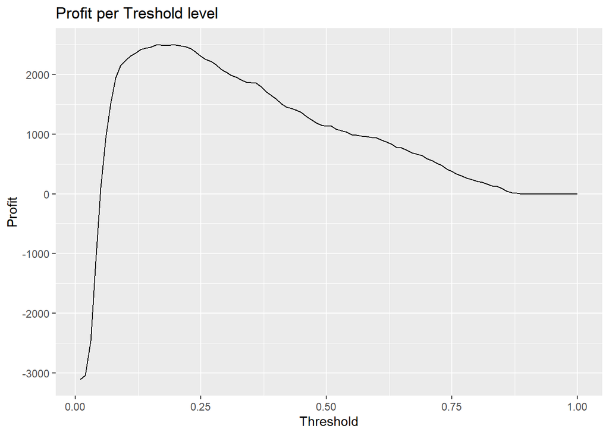

```r
ggplot(outcome, aes(x = threshold, y = profit)) +
  geom_line() +
  labs(x = "Threshold", y = "Profit", title = "Profit per Treshold level")
```

```r
#With the optimal threshold value we have:
log_pred_ME_binary <- ifelse(log_pred_ME >= 0.19, 1, 0)
opt_confmat <- confusionMatrix(as.factor(log_pred_ME_binary) , as.factor(log_test$yyes), positive = "1")
opt_confmat #this is the confusion matrix before applying weights
```

```
## Confusion Matrix and Statistics
##
##           Reference
## Prediction    0    1
##          0 8009  482
##          1  842  667
##
##                Accuracy : 0.8676
##                  95% CI : (0.8608, 0.8742)
##     No Information Rate : 0.8851
##     P-Value [Acc > NIR] : 1
##
##                   Kappa : 0.4271
##
##  Mcnemar's Test P-Value : <2e-16
##
##             Sensitivity : 0.5805
##             Specificity : 0.9049
##          Pos Pred Value : 0.4420
##          Neg Pred Value : 0.9432
##              Prevalence : 0.1149
##          Detection Rate : 0.0667
##    Detection Prevalence : 0.1509
##       Balanced Accuracy : 0.7427
##
##        'Positive' Class : 1
##
```

```r
opt_conf_mat_wg <- confmat$table*outcome_weights
opt_conf_mat_wg #this is the confusion matrix after applying the weights
```

```
##           Reference
## Prediction 0 1
##          0 0 0
##          1 0 0
```

# 4 KNN Model

The first KNN model we tried was simple with k=1 nearest neighbors. This gives us an idea of a starting point to determine the optimal KNN model for the call center to use.

```r
#Base model
knn_model_first <- knn(tele_train , tele_test , cl = tele_train_labels, k = 1)
confusionMatrix(as.factor(knn_model_first) , as.factor(tele_test_labels) , positive = "1")
```

```
## Confusion Matrix and Statistics
##
##           Reference
## Prediction    0    1
##          0 8089  785
##          1  762  364
##
##                Accuracy : 0.8453
##                  95% CI : (0.8381, 0.8523)
##     No Information Rate : 0.8851
##     P-Value [Acc > NIR] : 1.0000
##
##                   Kappa : 0.2327
##
##  Mcnemar's Test P-Value : 0.5759
##
##             Sensitivity : 0.3168
##             Specificity : 0.9139
##          Pos Pred Value : 0.3233
##          Neg Pred Value : 0.9115
##              Prevalence : 0.1149
##          Detection Rate : 0.0364
##    Detection Prevalence : 0.1126
##       Balanced Accuracy : 0.6154
##
##        'Positive' Class : 1
##
```

As shown in the confusion Matrix, this KNN model is missing a large amount of successful calls (false negatives) and therefore is missing out on a large amount of potential profit. To determine the optimal K value we can run various for loops which test different k values for both accuracy and profitability (taking opportunity cost into account).

## 4.1 Finding optimal k value based on model accuracy

```r
#Using a loop to test k=1 to k=10 to determine k value with highest accuracy

accuracies<- c()
for (i in 1:10){
    knn.mod <-  knn(train=tele_train, test=tele_test, cl=tele_train_labels, k=i)
    optm_k <- 100 * sum(tele_test_labels == knn.mod)/NROW(tele_test_labels)
    k=i
    accuracies <- append(accuracies, optm_k)
    cat(k,'=',optm_k,'\n')       # to print % accuracy
}
```

```
## 1 = 84.6
## 2 = 84.66
## 3 = 88.21
## 4 = 88.17
## 5 = 89.03
## 6 = 88.88
## 7 = 89.23
## 8 = 89.27
## 9 = 89.25
## 10 = 89.28
```

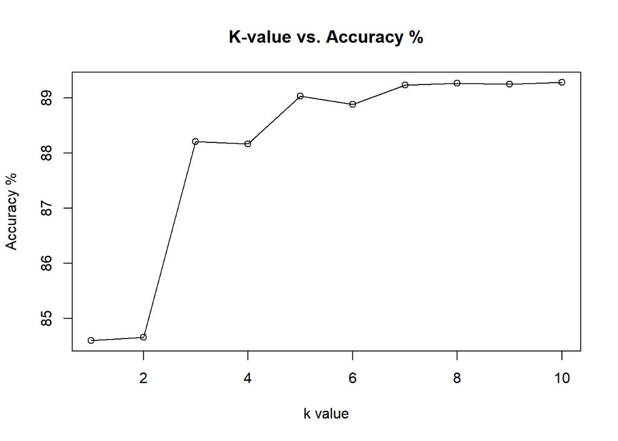

```r
#Line plot showing the k values 1-10 vs. the accuracy
plot(accuracies, type = "o", xlab="k value", ylab = "Accuracy %", main = "K-value vs. Accuracy %")
```

## 4.2 Finding financially optimal k value

```r
#Using a loop to test k=1 to k=10 to determine k value that yields the largest profit

profits <- c()
for (i in 1:10){
  knn.mod2 <-  knn(train=tele_train, test=tele_test, cl=tele_train_labels, k=i)
  crosstab <- CrossTable(knn.mod2 , tele_test_labels, prop.r = FALSE, prop.c = FALSE, prop.t = FALSE, prop.chisq = FALSE)
  A <- crosstab$t['0','0']
  B <- crosstab$t['1','0']
  C <- crosstab$t['0','1']
  D <- crosstab$t['1','1']

  profit <- (A)-(5*B)-(C)+(5*D)
  profits <- append(profits, profit)

  cat('k =', i, 'then profit = $', profit, '\n')
}
```

```
##
##
##    Cell Contents
## |-------------------------|
## |                       N |
## |-------------------------|
##
##
## Total Observations in Table:  10000
##
##
##              | tele_test_labels
##     knn.mod2 |         0 |         1 | Row Total |
## -------------|-----------|-----------|-----------|
##            0 |      8091 |       786 |      8877 |
## -------------|-----------|-----------|-----------|
##            1 |       760 |       363 |      1123 |
## -------------|-----------|-----------|-----------|
## Column Total |      8851 |      1149 |     10000 |
## -------------|-----------|-----------|-----------|
##
##
## k = 1 then profit = $ 5320
##
##
##    Cell Contents
## |-------------------------|
## |                       N |
## |-------------------------|
##
##
## Total Observations in Table:  10000
##
##
##              | tele_test_labels
##     knn.mod2 |         0 |         1 | Row Total |
## -------------|-----------|-----------|-----------|
##            0 |      8154 |       796 |      8950 |
## -------------|-----------|-----------|-----------|
##            1 |       697 |       353 |      1050 |
```

[output cut: 175 more lines]

```
## Total Observations in Table:  10000
##
##
##              | tele_test_labels
##     knn.mod2 |         0 |         1 | Row Total |
## -------------|-----------|-----------|-----------|
##            0 |      8679 |       909 |      9588 |
## -------------|-----------|-----------|-----------|
##            1 |       172 |       240 |       412 |
## -------------|-----------|-----------|-----------|
## Column Total |      8851 |      1149 |     10000 |
## -------------|-----------|-----------|-----------|
##
##
## k = 10 then profit = $ 8110
```

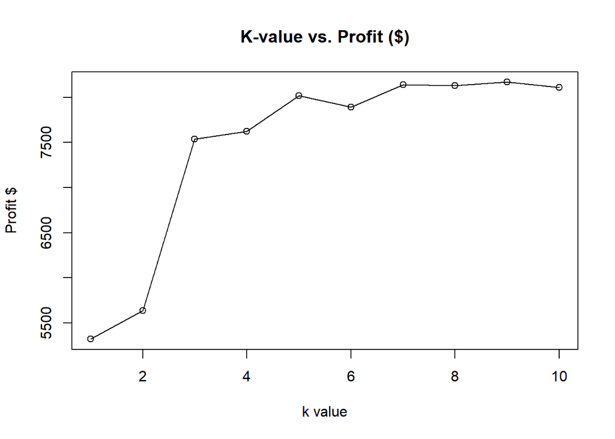

```r
#Line plot showing the k values 1-10 vs. profit
plot(profits, type = "o", xlab="k value", ylab = "Profit $", main = "K-value vs. Profit ($)")
```

```r
optimal_knn_pred <- knn(tele_train , tele_test , cl = tele_train_labels, k = 9)

confusionMatrix(as.factor(optimal_knn_pred) , as.factor(tele_test_labels) , positive = "1")
```

```
## Confusion Matrix and Statistics
##
##           Reference
## Prediction    0    1
##          0 8680  906
##          1  171  243
##
##                Accuracy : 0.8923
##                  95% CI : (0.8861, 0.8983)
##     No Information Rate : 0.8851
##     P-Value [Acc > NIR] : 0.01195
##
##                   Kappa : 0.2663
##
##  Mcnemar's Test P-Value : < 2e-16
##
##             Sensitivity : 0.2115
##             Specificity : 0.9807
##          Pos Pred Value : 0.5870
##          Neg Pred Value : 0.9055
##              Prevalence : 0.1149
##          Detection Rate : 0.0243
##    Detection Prevalence : 0.0414
##       Balanced Accuracy : 0.5961
##
##        'Positive' Class : 1
##
```

# 5 ANN Model

Per our discussion with Professor Kumar, we attempted to run an ANN model on the data using 1, 5, and 20 as potential hidden values. In the first two code blocks below, you can see our code which runs an ANN model using both 1 and 5 for hidden values and saving them to RDS files respectively. However, due to the limited computing power of our personal laptops, we were unable to get an ANN model with hidden = 20 to run successfully. The code which we unsuccessfully attempted is also illustrated below in the third code block.

We chose to save each model into an RDS file then mark that code block as eval=FALSE because it prevents the computer from having to re-run the ANN model each time the file is knitted while still being able to keep the entire project on one cohesive rmd and html.

## 5.1 ANN with 1 Hidden

Below is the code which generates an ANN model with hidden = 1.

```r
ann_model_1hidden <- neuralnet(yyes ~ . , data = log_train, hidden = 1)
saveRDS(ann_model_1hidden , "ann_1hidden.rds")

# do 1 hidden, then 5, then 20 if possible
```

## 5.2 ANN with 5 Hidden

Below is the code which generates an ANN model with hidden = 5.

```r
ann_model_5hidden <- neuralnet(yyes ~ . , data = log_train, hidden = 5)
saveRDS(ann_model_5hidden , "ann_5hidden.rds")
```

## 5.3 ANN with 20 Hidden

Below is the code which would have generated an ANN model with hidden = 20, had our computers had enough computing resources to build the train the model.

```r
ann_model_20hidden <- neuralnet(yyes ~ . , data = log_train, hidden = 20)
saveRDS(ann_model_20hidden , "ann_20hidden.rds")
```

## 5.4 ANN Prediction

Now that we have an ANN model with a hidden = 5, we can use that model to predict outcomes using out test data. This follows the same process as usual by first loading the RDS file into the code bloc, then using the predict function, and finally generating a confusion matrix to visualize the accuracy of our prediction against the real outcomes in the test data.

```r
hidden5_RDS <- readRDS("ann_5hidden.rds")
pred_5hidden <- predict(hidden5_RDS , log_test)
# we need to optimize the profits based on what we have for the threshold under binarypred_5hidden
binarypred_5hidden <- ifelse(pred_5hidden >= 0.5 , 1, 0)

confusionMatrix(as.factor(binarypred_5hidden) , as.factor(log_test$yyes) , positive = "1")
```

```
## Confusion Matrix and Statistics
##
##           Reference
## Prediction    0    1
##          0 8642  842
##          1  209  307
##
##                Accuracy : 0.8949
##                  95% CI : (0.8887, 0.9008)
##     No Information Rate : 0.8851
##     P-Value [Acc > NIR] : 0.0009929
##
##                   Kappa : 0.3204
##
##  Mcnemar's Test P-Value : < 2.2e-16
##
##             Sensitivity : 0.2672
##             Specificity : 0.9764
##          Pos Pred Value : 0.5950
##          Neg Pred Value : 0.9112
##              Prevalence : 0.1149
##          Detection Rate : 0.0307
##    Detection Prevalence : 0.0516
##       Balanced Accuracy : 0.6218
##
##        'Positive' Class : 1
##
```

In order for the call center to maximize profits using this model, we need to determine the optimal threshold for creating the binary 0 and 1 prediction of if they should call or not. Like in the logistic regression, it is important that we do not only care about overall accuracy, but also the sensitivity vs the specificity. In this case we want to boost the sensitivity as much as we can without sacrificing too much specificity. This is because from a business standpoint, each successful call gains 6 dollars in revenue whereas each unsuccessful call only costs 1 dollar. Therefore, we care much more about catching as many 1s as we can in this model at the expense of picking up some false positives in our prediction. See the following section for code which optimizes the threshold.

### 5.4.1 Optimizing Binary Prediction Threshold to Maximize Profits

As stated above, we need to code a for loop to find the threshold which will maximize profits for the call center. This process followed directly mirrors that in the logistic regression model.

```r
confmat_ann <- confusionMatrix(as.factor(binarypred_5hidden) , as.factor(log_test$yyes), positive = "1")

confmat_ann
```

```
## Confusion Matrix and Statistics
##
##           Reference
## Prediction    0    1
##          0 8642  842
##          1  209  307
##
##                Accuracy : 0.8949
##                  95% CI : (0.8887, 0.9008)
##     No Information Rate : 0.8851
##     P-Value [Acc > NIR] : 0.0009929
##
##                   Kappa : 0.3204
##
##  Mcnemar's Test P-Value : < 2.2e-16
##
##             Sensitivity : 0.2672
##             Specificity : 0.9764
##          Pos Pred Value : 0.5950
##          Neg Pred Value : 0.9112
##              Prevalence : 0.1149
##          Detection Rate : 0.0307
##    Detection Prevalence : 0.0516
##       Balanced Accuracy : 0.6218
##
##        'Positive' Class : 1
##
```

```r
outcome_weights_ann <- matrix(
          c(0, 0,
          -1, 5),
          nrow = 2,
          byrow = TRUE
)


conf_mat_wg_ann <- sum(confmat_ann$table*outcome_weights_ann)
str(conf_mat_wg_ann)
```

```
##  num 1326
```

```r
outcome_ann <- data.frame(threshold = numeric(), profit = numeric())

threshold_list_ann <- seq(from = 0.01, to = 1, by = 0.01)

for (i in threshold_list_ann) {
  binarypred_5hidden <- ifelse(pred_5hidden >= i, 1, 0)
  confmat_ann <- confusionMatrix(as.factor(binarypred_5hidden) , as.factor(log_test$yyes), positive = "1")
  out <- sum(confmat_ann$table*outcome_weights_ann)
  nrow <- data.frame(threshold = i, profit = out)
  outcome_ann <- rbind(outcome_ann,nrow)
}

outcome_ann
```

```
##     threshold profit
## 1        0.01  -2980
## 2        0.02  -2794
## 3        0.03  -2423
## 4        0.04  -1391
## 5        0.05    -19
## 6        0.06    900
## 7        0.07   1667
## 8        0.08   2099
## 9        0.09   2256
## 10       0.10   2407
## 11       0.11   2418
## 12       0.12   2416
## 13       0.13   2400
## 14       0.14   2415
```

[output cut: 86 more lines]

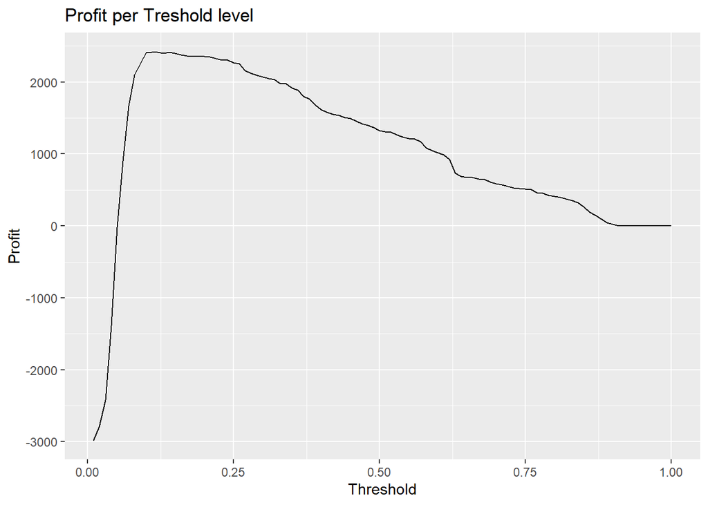

```r
ggplot(outcome_ann, aes(x = threshold, y = profit)) +
  geom_line() +
  labs(x = "Threshold", y = "Profit", title = "Profit per Treshold level")
```

```r
# the optimal threshold looking at the table and plot is 0.11, so let's generate a prediction and confusionMatrix using said value

binarypred_5hidden <- ifelse(pred_5hidden >= 0.11 , 1, 0)

confusionMatrix(as.factor(binarypred_5hidden) , as.factor(log_test$yyes) , positive = "1")
```

```
## Confusion Matrix and Statistics
##
##           Reference
## Prediction    0    1
##          0 7909  477
##          1  942  672
##
##                Accuracy : 0.8581
##                  95% CI : (0.8511, 0.8649)
##     No Information Rate : 0.8851
##     P-Value [Acc > NIR] : 1
##
##                   Kappa : 0.4068
##
##  Mcnemar's Test P-Value : <2e-16
##
##             Sensitivity : 0.5849
##             Specificity : 0.8936
##          Pos Pred Value : 0.4164
##          Neg Pred Value : 0.9431
##              Prevalence : 0.1149
##          Detection Rate : 0.0672
##    Detection Prevalence : 0.1614
##       Balanced Accuracy : 0.7392
##
##        'Positive' Class : 1
##
```

Therefore, the optimal threshold for the ANN model prediction is 0.11.

# 6 Combining Models Together

To combine the three models together, we created a new variable which was a sum of all the predictions from the three different models. To do this, we first had to convert the KNN predictions into a number (from a factor), and then we can sum them using simple addition. Next, we created a new variable, binary_combined_call which was equal to 1 if at least 2 models predicted a successful call, else 0. Below you can see the code we used for this process and the confusion matrix comparing the predicted outcome to real outcomes with the test data using all three models combined.

```r
#first we have to convert optimal_knn_pred into a number

optimal_knn_pred <- as.numeric(as.character(optimal_knn_pred))

summed_predictions <- optimal_knn_pred + binarypred_5hidden + log_pred_ME_binary

binary_combined_call <- ifelse(summed_predictions >= 2 , 1, 0)

confusionMatrix(as.factor(binary_combined_call) , as.factor(log_test$yyes) , positive = "1")
```

```
## Confusion Matrix and Statistics
##
##           Reference
## Prediction    0    1
##          0 8105  514
##          1  746  635
##
##                Accuracy : 0.874
##                  95% CI : (0.8673, 0.8804)
##     No Information Rate : 0.8851
##     P-Value [Acc > NIR] : 0.9997
##
##                   Kappa : 0.4305
##
##  Mcnemar's Test P-Value : 7.632e-11
##
##             Sensitivity : 0.5527
##             Specificity : 0.9157
##          Pos Pred Value : 0.4598
##          Neg Pred Value : 0.9404
##              Prevalence : 0.1149
##          Detection Rate : 0.0635
##    Detection Prevalence : 0.1381
##       Balanced Accuracy : 0.7342
##
##        'Positive' Class : 1
##
```

# 7 Results and Analysis

Ultimately, all of our technical analysis is only useful once we can analyze the results and what this means for the business. As previously mentioned, we created, optimized, and ran four different models – with one being the combination of the three – and can now analyze our results. For each model we used a confusion matrix to analyze our results. Each confusion matrix gives us four scenarios: 1. Correct positive predictions 2. Correct negative prediction 3. False positive prediction 4. False negative prediction. Each of these four values can be directly attributed to a financial result as we know that each call cost $1 and a successful call results in $6 in revenue. Therefore, in situation 1 (correct positive prediction) we earn $5 in profit ($6 revenue - $1 in call cost), situation 2 we earn $1 in opportunity cost because we do not call someone who wouldn’t buy our product, situation 3 we earn $-1 in real profit because we call someone unsuccessfully, and in situation 4 we earn $-5 in opportunity cost profit because we do not call someone who would have purchased our product.

Understanding all four scenarios is crucial to optimize our models for both accounting profit and opportunity cost as this is the most accurate representation of an optimal business scenario. Therefore, we used each of these four different scenarios, and their attributed financial impact, when optimizing our models. However, when analyzing the final results of each model, we are only looking at bottom-line profit as this is what the company would ultimately experience in terms of business impact. This profit analysis can be done simply by completing the equation:

Profit = (# of successful calls) * $6 - (# of total calls) * $1

Final Logistic Regression Confusion matrix results: 1. Correct positive predictions = 667 2. Correct negative prediction = 8009 3. False positive prediction = 842 4. False negative prediction = 482

Profit = (667 successful calls) * $6 - (667 + 842) * $1 Profit = $4002 - $1509 Profit = $2,493

Final KNN Model Confusion matrix results: 1. Correct positive predictions = 243 2. Correct negative prediction = 8680 3. False positive prediction = 171 4. False negative prediction = 906

Profit = (243 successful calls) * $6 - (243 + 171) * $1 Profit = $1458 - $414 Profit = $1,044

Final ANN Model Confusion matrix results: 1. Correct positive predictions = 672 2. Correct negative prediction = 7909 3. False positive prediction = 942 4. False negative prediction = 477

Profit = (672 successful calls) * $6 - (672 + 942) * $1 Profit = $4032 - $1614 Profit = $2,418

Combined Model Confusion matrix results: 1. Correct positive predictions = 635 2. Correct negative prediction = 8105 3. False positive prediction = 746 4. False negative prediction = 514

Profit = (635 successful calls) * $6 - (635 + 746) * $1 Profit = $3810 - $1381 Profit = $2,429

The final result of this analysis shows that the logistic regression model yields the highest at $2,493 from a test size of 10,000 customers. While it may have seemed logical that our combined model would be the best model, our profit analysis shows otherwise. One reason may be because the KNN model has a much smaller amount of total calls than the other two models which results in the combined having fewer total calls than the logistic regression model as well.

# 8 Conclusion

Our group was posed with the problem of trying to improve the profitability of a telemarketing call center. Before our group’s analysis, the call center operated with an 11.26% success rate and its operating profit requires a 16% success rate to break even. This gap clearly shows that the call center’s historic success rate would result in negative profitability and our goal was to turn this around.

After building, optimizing, and running four different models we have come to the conclusion that the best predictive model that this call bank can use is our logistic regression model. Using a test group of 10,000 potential customers, our logistic regression model results in 1,509 calls of which 667 will be successful, yielding a profit of $2,493. Our success rate on calls is 44% (667/1509) which far and away clears the 16% hurdle needed to break even.